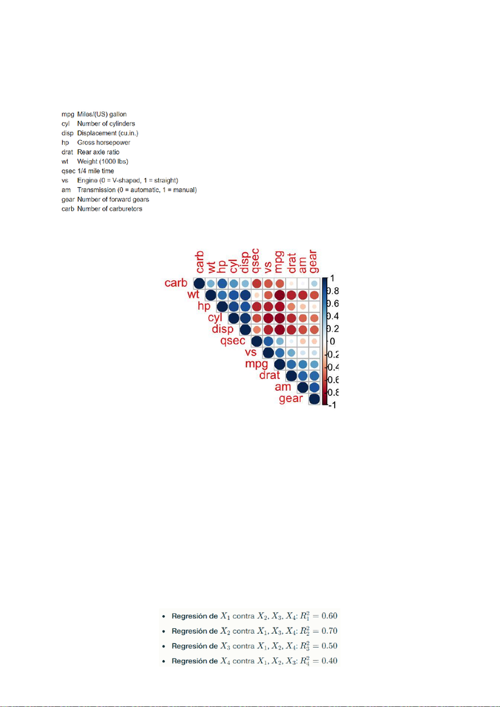

Ejercicios adicionales sobre multicolinealidad

1) A continuación se muestran el listado de las covariables X’s de un modelo de regresión.

En la siguiente figura se muestra gráficamente las correlaciones entre las variables explicativas.

a. ¿Cuáles covariables son las que están más correlacionadas de forma positiva?

b. ¿Cuáles covariables son las que están más correlacionadas de forma negativa?

c. ¿Por qué la diagonal principal de la matriz anterior tiene color azul intenso?

d. ¿Será que hay alguna covariable que es combinación lineal de otras covariables?

Rtas: las respuestas se obtienen por simple observación de la figura.

2) Se piensa crear un modelo de regresión para explicar la variable 𝑌 en función de 4 covariables 𝑋 pero antes

queremos explorar si existen problemas de multicolinealidad entre las covariables. A continuación se

muestran los coeficientes de determinación entre una covariable y las restantes.

[figure not shown]

Usando los resultados anteriores calcule los cuatro VIF e diga si hay problemas de multicolinealidad o no.

Rta: VIF1=2.5, VIF2=3.33, VIF3=2.0, VIF4=1.67. Como todos los VIF son menores o iguales a cinco, podemos decir que no

hay problemas de multicolinealidad.

3) Un investigador está estudiando la relación entre el rendimiento laboral (Y) y cuatro variables predictoras:

años de experiencia (X1), nivel educativo (X2), habilidades técnicas (X3) y motivación (X4). Para determinar si

hay problemas de multicolinealidad en el modelo de regresión lineal múltiple, usted debe calcular el número

Rta: 𝑘 = 32 y √𝑘 = 5.66, por lo tanto, no hay problemas de multicolinealidad.

4) Usando los datos del ejercicio anterior, calcule los índices de condición y diga si hay multicolinealidad.

Rta: los cinco índices de condición son 1, 4, 6.4, 8 y 32. La raíz cuadrada más grande de los índices anteriores es 5.66 y

por lo tanto no hay problemas de multicolinealidad.